# p8105_hw1_qz2527

kindle zhang

2023-09-16

## Problem 1

1. load the data set

```r
data("early_january_weather")
```

2. describe the data

```r
summary(early_january_weather)
```

```
##     origin               year          month        day              hour
##  Length:358         Min.   :2013   Min.   :1   Min.   : 1.000   Min.   : 0.00
##  Class :character   1st Qu.:2013   1st Qu.:1   1st Qu.: 4.000   1st Qu.: 6.00
##  Mode  :character   Median :2013   Median :1   Median : 8.000   Median :11.50
##                     Mean   :2013   Mean   :1   Mean   : 8.039   Mean   :11.53
##                     3rd Qu.:2013   3rd Qu.:1   3rd Qu.:12.000   3rd Qu.:17.75
##                     Max.   :2013   Max.   :1   Max.   :15.000   Max.   :23.00
##
##       temp            dewp           humid           wind_dir
##  Min.   :24.08   Min.   : 8.96   Min.   : 32.86   Min.   :  0.0
##  1st Qu.:33.98   1st Qu.:19.94   1st Qu.: 51.34   1st Qu.:140.0
##  Median :39.02   Median :26.06   Median : 61.67   Median :240.0
##  Mean   :39.58   Mean   :28.06   Mean   : 65.48   Mean   :208.2
##  3rd Qu.:44.96   3rd Qu.:35.06   3rd Qu.: 78.68   3rd Qu.:290.0
##  Max.   :57.92   Max.   :53.06   Max.   :100.00   Max.   :360.0
##                                                   NA's   :5
##    wind_speed       wind_gust         precip            pressure
##  Min.   : 0.000   Min.   :16.11   Min.   :0.000000   Min.   :1011
##  1st Qu.: 5.754   1st Qu.:19.56   1st Qu.:0.000000   1st Qu.:1018
##  Median : 8.055   Median :21.86   Median :0.000000   Median :1022
##  Mean   : 8.226   Mean   :22.53   Mean   :0.002039   Mean   :1023
##  3rd Qu.:11.508   3rd Qu.:25.32   3rd Qu.:0.000000   3rd Qu.:1027
##  Max.   :24.166   Max.   :31.07   Max.   :0.190000   Max.   :1034
##                   NA's   :308                        NA's   :38
##      visib          time_hour
##  Min.   : 0.120   Min.   :2013-01-01 01:00:00.00
##  1st Qu.: 9.000   1st Qu.:2013-01-04 19:15:00.00
##  Median :10.000   Median :2013-01-08 12:30:00.00
##  Mean   : 8.515   Mean   :2013-01-08 12:28:09.39
##  3rd Qu.:10.000   3rd Qu.:2013-01-12 05:45:00.00
##  Max.   :10.000   Max.   :2013-01-15 23:00:00.00
##
```

```r
# or use head(early_january_weather)
skimr::skim(early_january_weather)
```

Data summary

| Name | early_january_weather |
| --- | --- |
| Number of rows | 358 |
| Number of columns | 15 |
| _______________________ |  |
| Column type frequency: |  |
| character | 1 |
| numeric | 13 |
| POSIXct | 1 |
| ________________________ |  |
| Group variables | None |

**Variable type: character**

| skim_variable | n_missing | complete_rate | min | max | empty | n_unique | whitespace |
| --- | --- | --- | --- | --- | --- | --- | --- |
| origin | 0 | 1 | 3 | 3 | 0 | 1 | 0 |

**Variable type: numeric**

| skim_variable | n_missing | complete_rate | mean | sd | p0 | p25 | p50 | p75 | p100 | hist |
| --- | --- | --- | --- | --- | --- | --- | --- | --- | --- | --- |
| year | 0 | 1.00 | 2013.00 | 0.00 | 2013.00 | 2013.00 | 2013.00 | 2013.00 | 2013.00 | ▁▁▇▁▁ |
| month | 0 | 1.00 | 1.00 | 0.00 | 1.00 | 1.00 | 1.00 | 1.00 | 1.00 | ▁▁▇▁▁ |
| day | 0 | 1.00 | 8.04 | 4.31 | 1.00 | 4.00 | 8.00 | 12.00 | 15.00 | ▇▇▇▇▇ |
| hour | 0 | 1.00 | 11.53 | 6.92 | 0.00 | 6.00 | 11.50 | 17.75 | 23.00 | ▇▇▆▇▇ |
| temp | 0 | 1.00 | 39.58 | 7.06 | 24.08 | 33.98 | 39.02 | 44.96 | 57.92 | ▃▇▇▇▁ |
| dewp | 0 | 1.00 | 28.06 | 10.73 | 8.96 | 19.94 | 26.06 | 35.06 | 53.06 | ▃▇▆▂▃ |
| humid | 0 | 1.00 | 65.48 | 18.95 | 32.86 | 51.34 | 61.67 | 78.68 | 100.00 | ▃▇▆▂▅ |
| wind_dir | 5 | 0.99 | 208.19 | 115.58 | 0.00 | 140.00 | 240.00 | 290.00 | 360.00 | ▅▁▂▇▆ |
| wind_speed | 0 | 1.00 | 8.23 | 4.61 | 0.00 | 5.75 | 8.06 | 11.51 | 24.17 | ▅▇▆▂▁ |
| wind_gust | 308 | 0.14 | 22.53 | 3.63 | 16.11 | 19.56 | 21.86 | 25.32 | 31.07 | ▅▇▃▇▁ |
| precip | 0 | 1.00 | 0.00 | 0.01 | 0.00 | 0.00 | 0.00 | 0.00 | 0.19 | ▇▁▁▁▁ |
| pressure | 38 | 0.89 | 1022.52 | 5.57 | 1010.80 | 1018.30 | 1022.05 | 1027.23 | 1034.40 | ▃▇▇▇▃ |
| visib | 0 | 1.00 | 8.52 | 3.00 | 0.12 | 9.00 | 10.00 | 10.00 | 10.00 | ▁▁▁▁▇ |

**Variable type: POSIXct**

| skim_variable | n_missing | complete_rate | min | max | median | n_unique |
| --- | --- | --- | --- | --- | --- | --- |
| time_hour | 0 | 1 | 2013-01-01 01:00:00 | 2013-01-15 23:00:00 | 2013-01-08 12:30:00 | 358 |

```r
data_row = nrow(early_january_weather)
data_col = ncol(early_january_weather)
mean_temp = mean(early_january_weather$temp)
```

the variables in this data set are: day, dewp, hour, humid, month, origin, precip, pressure, temp, time_hour, visib, wind_dir, wind_gust, wind_speed, year

the size of the data set is 358 rows and 15 columns

the mean temputure is 39.5821229

3. plot

make a data table first and use `ggplot` to plot the image

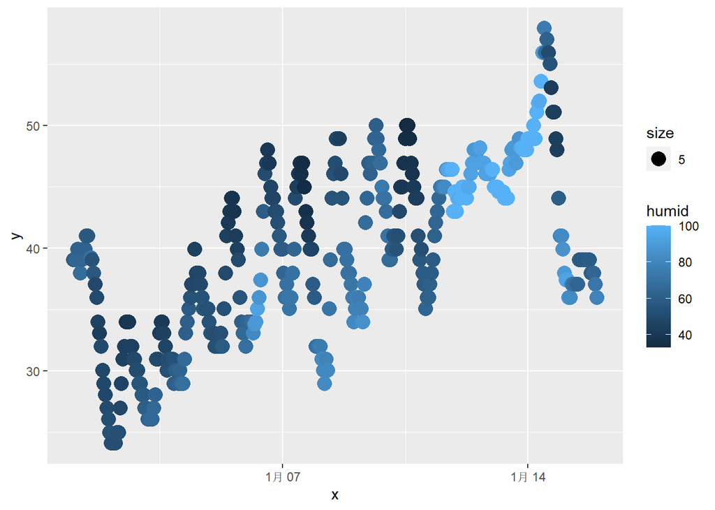

```r
my_plot = tibble(
  x = early_january_weather$time_hour,
  y = early_january_weather$temp,
  humid = early_january_weather$humid
)
ggplot(my_plot, aes(x = x, y = y, group = humid)) + geom_point(aes(color = humid, size = 5))
```

```r
ggsave("hw1_plot_1.png")
```

## Problem 2

Create a data frame comprised of:

a random sample of size 10 from a standard Normal distribution a logical vector indicating whether elements of the sample are greater than 0 a character vector of length 10 a factor vector of length 10, with 3 different factor “levels” Try to take the mean of each variable in your dataframe. What works and what doesn’t?

```r
my_data_2 = tibble(
  norm_data = rnorm(10),
  log_vec = norm_data > 0,
  cha_vec = c("12","22","24","123","22424","2","2424","22","24","244442"),
  fac_vec = factor(c("M","XL","L","M","XL","L","M","XL","L","M"))
)

mean_nd = mean(pull(my_data_2, norm_data))
mean_lv = mean(pull(my_data_2, log_vec))
mean_cv = mean(pull(my_data_2, cha_vec))
mean_fv = mean(pull(my_data_2, fac_vec))
```

- we can find the mean of numeric and logical variable exists,which are 0.1565111 and 0.6 but the mean of factor and character don’t exist.

the mean of the logical variable is the *proportion* of “True” in total samples

```r
mean_lv_2 = mean(as.numeric(my_data_2$log_vec))
mean_cv_2 = mean(as.numeric(my_data_2$cha_vec))
mean_fv_2 = mean(as.numeric(my_data_2$fac_vec))
```

- we can find the character becomes numeric variable and if they are absolutely numbers, they can be calculated.
- the “true” becomes 1 and “false” becomes 0, then it can be calculated.
- the different levels in factor sequence becomes a sequence with a start number 1.
- according to what we find above, we can explain why a mean can be calculated when we use a `as.numeric` function.